# Practical Machine Learning Project

Donato Scarano

06 luglio 2018

# Introduction

Using devices such as Jawbone Up, Nike FuelBand, and Fitbit it is now possible to collect a large amount of data about personal activity relatively inexpensively. These type of devices are part of the quantified self movement - a group of enthusiasts who take measurements about themselves regularly to improve their health, to find patterns in their behavior, or because they are tech geeks. One thing that people regularly do is quantify how much of a particular activity they do, but they rarely quantify how well they do it. In this project, the goal is to use data from accelerometers on the belt, forearm, arm, and dumbell of 6 participants. They were asked to perform barbell lifts correctly and incorrectly in 5 different ways.

More information is available from the website here: http://web.archive.org/web/20161224072740/http:/groupware.les.inf.puc-rio.br/har (see the section on the Weight Lifting Exercise Dataset).

Data

The training data for this project are available here:

https://d396qusza40orc.cloudfront.net/predmachlearn/pml-training.csv

The test data are available here:

https://d396qusza40orc.cloudfront.net/predmachlearn/pml-testing.csv

The data for this project come from this source: http://web.archive.org/web/20161224072740/http:/groupware.les.inf.puc-rio.br/har.

# Description

One thing that people regularly do is quantify how much of a particular activity they do, but they rarely quantify how well they do it. In this project our goal will be to use data from accelerometers on the belt, forearm, arm, and dumbell of 6 participants.

The goal of this project is to predict the manner in which they did the exercise. This is the “classe” variable in the training set.

```r
library(caret)
```

```r
library(rpart.plot)
library(rpart)
library(randomForest)
library(ggplot2)
library(gbm)
training<-read.csv("pml-training.csv")
testing<-read.csv("pml-testing.csv")
dim(training)
```

```
## [1] 19622   160
```

```r
dim(testing)
```

```
## [1]  20 160
```

# Training and Testing

```r
set.seed(1234)
trainout<-createDataPartition(training$classe,p=0.7,list=FALSE)
train<-training[trainout,]
test<-training[-trainout,]
dim(train)
```

```
## [1] 13737   160
```

```r
dim(test)
```

```
## [1] 5885  160
```

# Cleaning the Data

Remove all columns that contains NA and remove features such as identification only variables and Near Zero Value.

```r
navar <- sapply(train, function(x) mean(is.na(x)))>0.95
train <- train[, navar==FALSE]
test  <- test[,navar==FALSE]
dim(train)
```

```
## [1] 13737    93
```

```r
dim(test)
```

```
## [1] 5885   93
```

```r
nzv<-nearZeroVar(train)
train<-train[,-nzv]
test<-test[,-nzv]
dim(train)
```

```
## [1] 13737    59
```

```r
dim(test)
```

```
## [1] 5885   59
```

```r
train<-train[,-(1:5)]
test<-test[,-(1:5)]
dim(train)
```

```
## [1] 13737    54
```

```r
dim(test)
```

```
## [1] 5885   54
```

# Model Prediction

Three methods will be used: Random Forests, Decision Tree and Generalized Boosted and the one with higher accuracy will be used for the prediction.

1. Random Forest

```r
set.seed(1234)
RFcheck<-trainControl(method = "cv", number = 3,verboseIter = FALSE)
RFmod<-train(classe~.,data=train, method="rf", trControl=RFcheck)
RFmod$finalModel
```

```
##
## Call:
##  randomForest(x = x, y = y, mtry = param$mtry)
##                Type of random forest: classification
##                      Number of trees: 500
## No. of variables tried at each split: 27
##
##         OOB estimate of  error rate: 0.23%
## Confusion matrix:
##      A    B    C    D    E  class.error
## A 3904    1    0    0    1 0.0005120328
## B    3 2653    2    0    0 0.0018811136
## C    0    5 2389    2    0 0.0029215359
## D    0    0    9 2242    1 0.0044404973
## E    0    1    0    6 2518 0.0027722772
```

Confusion Matrix and Satistics for Random Forest

```r
RFcst<-predict(RFmod, newdata = test)
CMRD<-confusionMatrix(RFcst,test$classe)
CMRD
```

```
## Confusion Matrix and Statistics
##
##           Reference
## Prediction    A    B    C    D    E
##          A 1674    3    0    0    0
##          B    0 1135    2    0    0
##          C    0    1 1024    1    0
##          D    0    0    0  963    4
##          E    0    0    0    0 1078
##
## Overall Statistics
##
##                Accuracy : 0.9981
##                  95% CI : (0.9967, 0.9991)
##     No Information Rate : 0.2845
##     P-Value [Acc > NIR] : < 2.2e-16
##
##                   Kappa : 0.9976
##  Mcnemar's Test P-Value : NA
##
## Statistics by Class:
##
##                      Class: A Class: B Class: C Class: D Class: E
## Sensitivity            1.0000   0.9965   0.9981   0.9990   0.9963
## Specificity            0.9993   0.9996   0.9996   0.9992   1.0000
## Pos Pred Value         0.9982   0.9982   0.9981   0.9959   1.0000
## Neg Pred Value         1.0000   0.9992   0.9996   0.9998   0.9992
## Prevalence             0.2845   0.1935   0.1743   0.1638   0.1839
## Detection Rate         0.2845   0.1929   0.1740   0.1636   0.1832
## Detection Prevalence   0.2850   0.1932   0.1743   0.1643   0.1832
## Balanced Accuracy      0.9996   0.9980   0.9988   0.9991   0.9982
```

Accuracy for the Random Forest method is: 1

2. Decision Trees

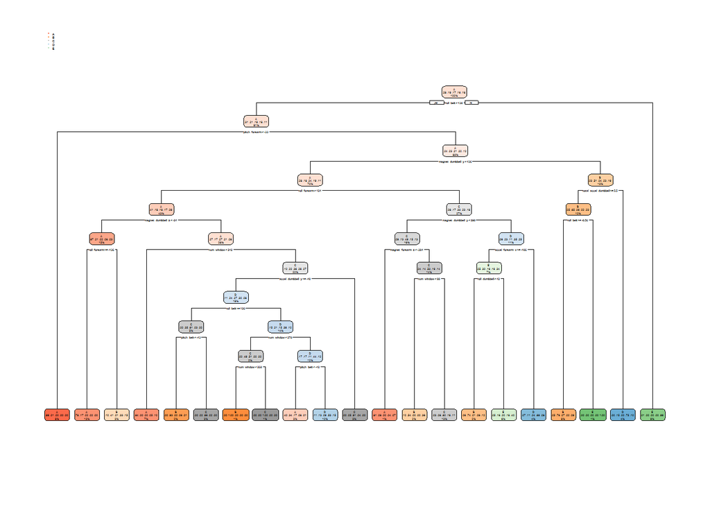

```r
set.seed(1234)
DTmod<-rpart(classe~.,data=train,method="class")
rpart.plot(DTmod)
```

Confusion Matrix and Satistics for Decision Tree

```r
DTfcst<-predict(DTmod,newdata=test,type="class")
CMDT<-confusionMatrix(DTfcst,test$classe)
CMDT
```

```
## Confusion Matrix and Statistics
##
##           Reference
## Prediction    A    B    C    D    E
##          A 1489  206   54   76   52
##          B   70  671   34   84  111
##          C   19   70  823  128   98
##          D   81  134   49  618  133
##          E   15   58   66   58  688
##
## Overall Statistics
##
##                Accuracy : 0.7288
##                  95% CI : (0.7172, 0.7401)
##     No Information Rate : 0.2845
##     P-Value [Acc > NIR] : < 2.2e-16
##
##                   Kappa : 0.6557
##  Mcnemar's Test P-Value : < 2.2e-16
##
## Statistics by Class:
##
##                      Class: A Class: B Class: C Class: D Class: E
## Sensitivity            0.8895   0.5891   0.8021   0.6411   0.6359
## Specificity            0.9079   0.9370   0.9352   0.9193   0.9590
## Pos Pred Value         0.7933   0.6918   0.7232   0.6089   0.7774
## Neg Pred Value         0.9538   0.9048   0.9572   0.9290   0.9212
## Prevalence             0.2845   0.1935   0.1743   0.1638   0.1839
## Detection Rate         0.2530   0.1140   0.1398   0.1050   0.1169
## Detection Prevalence   0.3189   0.1648   0.1934   0.1725   0.1504
## Balanced Accuracy      0.8987   0.7631   0.8687   0.7802   0.7974
```

3. Generalized Boosted

```r
set.seed(1234)
GBcheck<-trainControl(method = "repeatedcv", number = 3, repeats=1)
GBmod<-train(classe~.,data=train, method="gbm", trControl=GBcheck, verbose=FALSE)
GBmod$finalModel
```

```
## A gradient boosted model with multinomial loss function.
## 150 iterations were performed.
## There were 53 predictors of which 42 had non-zero influence.
```

Confusion Matrix and Satistics for Generalized Boosted

```r
GBfcst<-predict(GBmod,newdata=test,type="raw")
CMGB<-confusionMatrix(GBfcst,test$classe)
CMGB
```

```
## Confusion Matrix and Statistics
##
##           Reference
## Prediction    A    B    C    D    E
##          A 1673   10    0    0    0
##          B    0 1114    4   11    1
##          C    0   12 1021   11    3
##          D    1    3    1  942    9
##          E    0    0    0    0 1069
##
## Overall Statistics
##
##                Accuracy : 0.9888
##                  95% CI : (0.9858, 0.9913)
##     No Information Rate : 0.2845
##     P-Value [Acc > NIR] : < 2.2e-16
##
##                   Kappa : 0.9858
##  Mcnemar's Test P-Value : NA
##
## Statistics by Class:
##
##                      Class: A Class: B Class: C Class: D Class: E
## Sensitivity            0.9994   0.9781   0.9951   0.9772   0.9880
## Specificity            0.9976   0.9966   0.9946   0.9972   1.0000
## Pos Pred Value         0.9941   0.9858   0.9752   0.9854   1.0000
## Neg Pred Value         0.9998   0.9947   0.9990   0.9955   0.9973
## Prevalence             0.2845   0.1935   0.1743   0.1638   0.1839
## Detection Rate         0.2843   0.1893   0.1735   0.1601   0.1816
## Detection Prevalence   0.2860   0.1920   0.1779   0.1624   0.1816
## Balanced Accuracy      0.9985   0.9873   0.9949   0.9872   0.9940
```

Accuracy for the Generalized Boosted method is: 0.99

Random Forest has the best accuracy among the three choices and we apply it to the test dataset.

```r
testfcst<-predict(RFmod,testing)
testfcst
```

```
##  [1] B A B A A E D B A A B C B A E E A B B B
## Levels: A B C D E
```